# Setup

```python
# -*- coding: utf-8 -*-
%matplotlib inline

import agate
import warnings
import requests
import zipfile
import io
import json
import unicodedata

from vaderSentiment.vaderSentiment import SentimentIntensityAnalyzer

import pandas as pd
import numpy as np
import math
import matplotlib
import matplotlib.pyplot as plt
import locale
import arrow
import xml.etree.ElementTree as ET

from locale import atof
from dateutil import parser
from datetime import datetime

plt.style.use('fivethirtyeight')
matplotlib.rcParams['figure.figsize'] = (12, 6)
matplotlib.rcParams['font.size'] = 10

warnings.filterwarnings('ignore')
warnings.simplefilter('ignore')
```

[output not shown]

[output cut: 73 more lines]

# Trump Tweet analysis

A look at Trump's tweets since inauguration day.

### Data processing

- Date grouping columns

### Analysis

- Frequencies sliced several ways: By day, month, hour of day
- Rates: Tweets/day, Tweets/day/month
- Keyword searches

# Get data

*Only run this if you need to update the Trump tweet data, for example the first time you run this script.*

Source data pulled from: http://www.trumptwitterarchive.com/archive

- Time span: Jan. 20, 2017 to Aug. 31, 2018
- Click button to export JSON, which basically just fills in a textarea above the search interface. Copy/paste that text into a text file and save it as a json.

```python
with open('data/since-20170120.json') as f:
    jsondata = json.load(f)
    analyzer = SentimentIntensityAnalyzer()

for row in jsondata:
    try:
        text = row['text']
    except KeyError:
        text = row['full_text']
    vs = analyzer.polarity_scores(text)
    row['sentiment'] = vs

with open('data/since-20170120-processed.json', 'w') as f:
    json.dump(jsondata, f)
```

# Utilities

*Add helper functions here.*

```python
# Stub for helpers
# convert utc to est
def convertUTCtoFull(date):
    utc = arrow.get(date)
    return utc.to('US/Eastern').format('dddd, MMM D, YYYY h:mm A')

# convert to year
def convertUTCtoYear(date):
    utc = arrow.get(date)
    return utc.to('US/Eastern').format('YYYY')

# convert to month
def convertUTCtoMonth(date):
    utc = arrow.get(date)
    return utc.to('US/Eastern').format('MM')

# convert to year-month
def convertUTCtoYearMonth(date):
    utc = arrow.get(date)
    return utc.to('US/Eastern').format('YYYY-MM')

# convert to day
def convertUTCtoDay(date):
    utc = arrow.get(date)
    return utc.to('US/Eastern').format('D')

# convert to month/day
def convertUTCtoMonthDay(date):
    utc = arrow.get(date)
    return utc.to('US/Eastern').format('YYYY-MM-DD')

# convert to day of week
def convertUTCtoDayOfWeek(date):
    utc = arrow.get(date)
    return utc.to('US/Eastern').format('d')

# convert to time
def convertUTCtoHourOfDay(date):
    utc = arrow.get(date)
    return int(utc.to('US/Eastern').format('HH'))

# convert to week of year
def convertUTCtoWeekNumber(date):
    return int(date.strftime('%U'))

# convert to year + week of year
def convertUTCtoYearWeekNumber(date):
    utc = arrow.get(date)
    year = utc.to('US/Eastern').format('YYYY')
    weekno = int(date.strftime('%U'))
    return str(year) + '-' + str(weekno).zfill(2)

# Strip HTML
def stripHTML(html):
    tree = ET.fromstring(html)
    return ET.tostring(tree, encoding='utf8', method='text')

# Encode with closest thing to character
def encodeText(line):
    line = unicodedata.normalize('NFKD', line).encode('ascii','ignore')
    return line
```

# Data processing

Open the `json` file and then use the `json_normalize()` function to flatten it for use with Pandas, which doesn't like nested json.

```python
with open('data/since-20170120-processed.json') as f:
    jsondata = json.load(f)

normalized_json = pd.io.json.json_normalize(jsondata)

tweets = pd.DataFrame(normalized_json)
tweets['created_date'] = pd.to_datetime(tweets['created_at'])
tweets['id'] = tweets['id_str']
tweets.text.fillna(tweets.text, inplace=True)
```

Add many time grouping columns.

**IMPORTANT CAVEAT:** Not all of these differentiate between 2017 and 2018. When doing your analysis, take care that, say, tweets from Aug 2017 and Aug. 2018 aren't aggregated together later. (Unless that's your intention.)

```python
tweets['human_date'] = tweets['created_date'].apply(convertUTCtoFull)
tweets['month/day'] = tweets['created_date'].apply(convertUTCtoMonthDay)
tweets['year'] = tweets['created_date'].apply(convertUTCtoYear)
tweets['month'] = tweets['created_date'].apply(convertUTCtoMonth)
tweets['year_month'] = tweets['created_date'].apply(convertUTCtoYearMonth)
tweets['day'] = tweets['created_date'].apply(convertUTCtoDay)
tweets['day of week'] = tweets['created_date'].apply(convertUTCtoDayOfWeek)
tweets['hour'] = tweets['created_date'].apply(convertUTCtoHourOfDay)
tweets['week'] = tweets['created_date'].apply(convertUTCtoWeekNumber)
tweets['year_week'] = tweets['created_date'].apply(convertUTCtoYearWeekNumber)
tweets['text encoded'] = tweets['text'].apply(encodeText)
tweets.set_index('created_date', inplace=True)

tweets.head()
```

| created_date | created_at | favorite_count | id_str | is_retweet | retweet_count | sentiment.compound | sentiment.neg | sentiment.neu | sentiment.pos | source | ... | month/day | year | month | year_month | day | day of week | hour | week | year_week | text encoded |
| --- | --- | --- | --- | --- | --- | --- | --- | --- | --- | --- | --- | --- | --- | --- | --- | --- | --- | --- | --- | --- | --- |
| 2018-09-01 02:40:23 | Sat Sep 01 02:40:23 +0000 2018 | 21996 | 1035718986871320577 | False | 5540 | -0.4939 | 0.173 | 0.765 | 0.061 | Twitter for iPhone | ... | 2018-08-31 | 2018 | 08 | 2018-08 | 31 | 5 | 22 | 34 | 2018-34 | b'Still cant believe that Bloomberg violated a... |
| 2018-09-01 02:36:57 | Sat Sep 01 02:36:57 +0000 2018 | 18946 | 1035718119459893250 | False | 3885 | 0.7773 | 0.000 | 0.570 | 0.430 | Twitter for iPhone | ... | 2018-08-31 | 2018 | 08 | 2018-08 | 31 | 5 | 22 | 34 | 2018-34 | b'Great day in North Carolina where Republican... |
| 2018-09-01 02:35:28 | Sat Sep 01 02:35:28 +0000 2018 | 20129 | 1035717747936768000 | False | 5164 | -0.6643 | 0.107 | 0.893 | 0.000 | Twitter for iPhone | ... | 2018-08-31 | 2018 | 08 | 2018-08 | 31 | 5 | 22 | 34 | 2018-34 | b'The ABC/Washington Post Poll was by far the ... |
| 2018-09-01 02:25:38 | Sat Sep 01 02:25:38 +0000 2018 | 21855 | 1035715271418413056 | False | 5717 | 0.1511 | 0.080 | 0.799 | 0.121 | Twitter for iPhone | ... | 2018-08-31 | 2018 | 08 | 2018-08 | 31 | 5 | 22 | 34 | 2018-34 | b'.@Rasmussen_Poll just came out at 48% approv... |
| 2018-09-01 00:01:21 | Sat Sep 01 00:01:21 +0000 2018 | 31907 | 1035678961349668864 | False | 8506 | 0.0000 | 0.000 | 1.000 | 0.000 | Twitter for iPhone | ... | 2018-08-31 | 2018 | 08 | 2018-08 | 31 | 5 | 20 | 34 | 2018-34 | b'https://t.co/c79zLeREOA' |

5 rows × 23 columns

# Sources

```python
# tweets['source_clean'] = tweets['source'].apply(stripHTML)
# tweets['source_clean'].unique()

tweets['source'].unique()
```

```
array(['Twitter for iPhone', 'Media Studio', 'Twitter Web Client',
       'Twitter for iPad', 'Twitter Ads', 'Twitter for Android'], dtype=object)
```

# Frequencies

## Total Tweets

```python
len(tweets.index)
```

```
4575
```

## Tweets per hour

Trump loves the morning hours, especially the 6am-9am range.

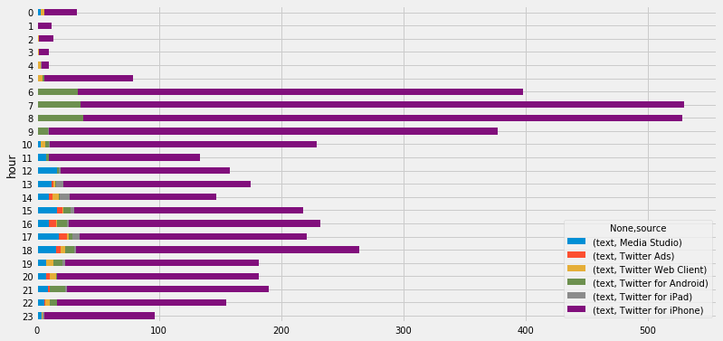

```python
tweetsPerHour = tweets[['source', 'hour', 'text']].pivot_table(
    index='hour', columns=['source'], aggfunc='count')
tweetsPerHour.to_csv('output/tweets-per-hour-of-day.csv')
tweetsPerHour.iloc[::-1].plot(kind='barh', stacked=True)
```

## Tweets per day

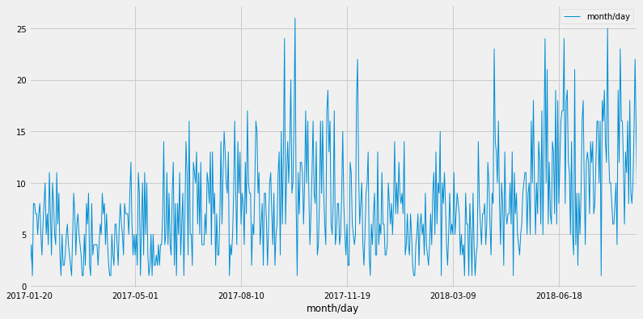

```python
tweetsPerDay = tweets[['month/day']].groupby(tweets['month/day']).count()
# tweetsPerDay.iloc[::-1].plot(kind='barh', figsize=(12,100), fontsize=8)
tweetsPerDay.plot(kind='line', linewidth=1.0)
```

```python
tweetsPerDay.describe()
```

|  | month/day |
| --- | --- |
| count | 575.000000 |
| mean | 7.956522 |
| std | 4.778712 |
| min | 1.000000 |
| 25% | 4.000000 |
| 50% | 7.000000 |
| 75% | 11.000000 |
| max | 26.000000 |

## Tweets per day of week

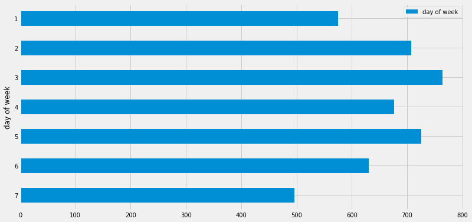

```python
tweetsPerDayOfWeek = tweets[['day of week']].groupby(tweets['day of week']).count()
tweetsPerDayOfWeek.iloc[::-1].plot(kind='barh')
# tweetsPerDayOfWeek.plot(kind='bar')
```

## Tweets per month

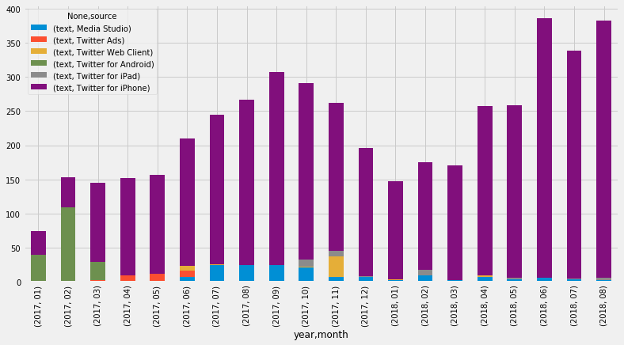

```python
baseMonth = tweets[['source', 'year', 'month', 'text']].pivot_table(index=['year', 'month'], columns=['source'], aggfunc='count')

tweetsPerMonth = tweets[['source', 'year', 'month', 'text']].pivot_table(index=['year', 'month'], columns=['source'], aggfunc='count')
tweetsPerMonth = tweetsPerMonth.reindex_like(baseMonth)
# tweetsPerMonth.iloc[::-1].plot(kind='bar', stacked=True)
tweetsPerMonth.plot(kind='bar', stacked=True)
```

## Tweets per week

**IMPORTANT CAVEATS:**

- Weeks (2017, 53) and (2018, 1) might be the same week
- The way we're handling weekly data assumes that Trump tweets at least once per week -- which, so far, has held true. But if there's ever a week where he *doesn't* tweet, then that could introduce a problem with the rendered charts. (The bar/week won't appear in the chart, and it might not be obvious that it's missing.)

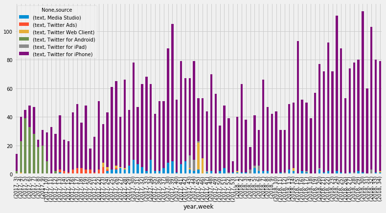

```python
tweetsPerWeek = tweets[['source', 'year', 'week', 'text']].pivot_table(index=['year', 'week'], columns=['source'], aggfunc='count')
tweetsPerWeek.to_csv('output/tweetsperweek-by-device.csv', na_rep=0)
tweetsPerWeek.plot(kind='bar', stacked=True)
```

# Text analysis

Common words.

```python
from collections import Counter
import nltk
import string
nltk.download('stopwords')
```

```
True
```

```python
top_N = 100
stopwords = nltk.corpus.stopwords.words('english')
stopwords = stopwords + ['rt']
# RegEx for stopwords
RE_stopwords = r'\b(?:{})\b'.format('|'.join(stopwords))
# replace '|'-->' ' and drop all stopwords
words = (tweets.text
           .str.lower()
           .replace([r'\|', RE_stopwords], [' ', ''], regex=True)
           .str.cat(sep=' ')
           .split()
)

# generate DF out of Counter
words_data = pd.DataFrame(Counter(words).most_common(300),
                    columns=['Word', 'Frequency']).set_index('Word')

pd.set_option('display.max_rows', top_N)
words_data = words_data.reset_index()
words_data['Word Encoded'] = words_data['Word'].apply(encodeText)
words_data.drop('Word', axis=1).to_csv('output/word-frequencies.csv')
words_data.head(top_N)
#pd.reset_option('display.max_rows')

# plot
# rslt.plot.bar(rot=0, figsize=(16,10), width=0.8)
```

|  | Word | Frequency | Word Encoded |
| --- | --- | --- | --- |
| 0 | great | 957 | b'great' |
| 1 | &amp; | 767 | b'&amp;' |
| 2 | ’ | 481 | b'' |
| 3 | ! | 433 | b'!' |
| 4 | - | 414 | b'-' |
| 5 | , | 390 | b',' |
| 6 | . | 371 | b'.' |
| 7 | people | 348 | b'people' |
| 8 | fake | 324 | b'fake' |
| 9 | big | 316 | b'big' |
| 10 | news | 300 | b'news' |
| 11 | thank | 296 | b'thank' |
| 12 | many | 290 | b'many' |
| 13 | president | 283 | b'president' |
| 14 | u.. | 272 | b'u..' |
| 15 | trump | 249 | b'trump' |
| 16 | ' | 225 | b"'" |
| 17 | american | 221 | b'american' |
| 18 | would | 221 | b'would' |
| 19 | much | 220 | b'much' |
| 20 | get | 214 | b'get' |
| 21 | tax | 214 | b'tax' |
| 22 | democrats | 212 | b'democrats' |
| 23 | must | 207 | b'must' |
| 24 | new | 199 | b'new' |
| 25 | america | 195 | b'america' |
| 26 | want | 193 | b'want' |
| 27 | make | 188 | b'make' |
| 28 | good | 180 | b'good' |
| 29 | time | 174 | b'time' |

[output cut: 70 more lines]

# Specific text searches

```python
from IPython.display import display, Markdown

tweetsEnc = tweets.reset_index()

def analyzeText(search):
    display(Markdown('## Search: _{0}_'.format(search)))
    filtered = tweetsEnc[tweetsEnc['text'].str.contains(search, case=False)]
    count = len(filtered)
    percent = float(len(filtered))/len(tweetsEnc) * 100
    display(Markdown('Number of Tweets: {0}'.format(count)))
    display(Markdown('Percent of all Tweets: {0:.2f}%'.format(percent)))

    # set up the base data frame for indexing purposes
    baseWeek = tweets[['source', 'year', 'week', 'text']].pivot_table(index=['year', 'week'], columns=['source'], aggfunc='count')
    baseMonth = tweets[['source', 'year', 'month', 'text']].pivot_table(index=['year', 'month'], columns=['source'], aggfunc='count')

    # set up the filtered data frame
    analyzedByWeek = filtered[['source', 'year', 'week', 'text']].pivot_table(index=['year', 'week'], columns=['source'], aggfunc='count')
    analyzedByMonth = filtered[['source', 'year', 'month', 'text']].pivot_table(index=['year', 'month'], columns=['source'], aggfunc='count')
    analyzedByHour = filtered[['source', 'hour', 'text']].pivot_table(index=['hour'], columns=['source'], aggfunc='count')

    # adjust the filtered data frame to use the index from the base data frame
    analyzedByWeek = analyzedByWeek.reindex_like(baseWeek)
    analyzedByMonth = analyzedByMonth.reindex_like(baseMonth)
    analyzedByHour = analyzedByHour.reindex(range(0, 24)).fillna(0)

    # output filtered csv
    analyzedByMonth.to_csv('output/word-by-month-{0}.csv'.format(search))
    analyzedByWeek.to_csv('output/word-by-week-{0}.csv'.format(search))
#     analyzedByHour.to_csv('output/word-by-hour-{0}.csv'.format(search))

    # spit out the plot
    analyzedByWeekPlot = analyzedByWeek.plot(kind='bar', stacked=True, title='{0} by week'.format(search))
    plt.show()

    analyzedByMonthPlot = analyzedByMonth.plot(kind='bar', stacked=True, title='{0} by month'.format(search))
    plt.show()

    analyzedByHourPlot = analyzedByHour.plot(kind='bar', stacked=True, title='{0} by hour of day'.format(search))
    plt.show()

#     analyzedByDay = filtered[['source', 'month/day', 'text']].pivot_table(index='month/day', columns=['source'], aggfunc='count')
#     analyzedByDay = analyzedByDay.reindex(range(tweetsEnc['month/day'].min(), tweetsEnc['month/day'].max())).fillna(0)
#     analyzedByDay = analyzedByDay.reindex(tweetsEnc['month/day']).fillna(0)

    display(Markdown('### The Tweets'))
    for i, row in filtered.iterrows():
        display(Markdown('[{0}](https://twitter.com/realDonaldTrump/status/{2}): {1}'.format(row['human_date'], row['text'], row['id'])))
    display(Markdown('---'))
```